# aircore

2024-08-26

```r
library(rtorf)
library(data.table)
```

```r
cate = c("aircraft-pfp",
         "aircraft-insitu",
         "aircraft-flask",
         "surface-insitu",
         "surface-flask",
         "surface-pfp",
         "tower-insitu",
         "aircore",
         "shipboard-insitu",
         "shipboard-flask")

obs <- "Z:/torf/obspack_ch4_1_GLOBALVIEWplus_v5.1_2023-03-08/data/nc/"
index <- obs_summary(obs = obs,
                     categories = cate)
```

```
#> Number of files of index: 429
#>               sector     N
#>               <char> <int>
#>  1:     aircraft-pfp    40
#>  2:  aircraft-insitu    15
#>  3:    surface-flask   106
#>  4:   surface-insitu   174
#>  5:   aircraft-flask     4
#>  6:          aircore     1
#>  7:      surface-pfp    33
#>  8:     tower-insitu    51
#>  9:  shipboard-flask     4
#> 10: shipboard-insitu     1
#> 11:    Total sectors   429
#> Detected 190 files with agl
#> Detected 239 files without agl
```

Now we read the `aircore` using the function `obs_read_nc`. To this date, `solar_time` is not included for aircraft, so we `FALSE` that argument.

```r
datasetid <- "aircore"
df <- obs_read_nc(index = index,
                  categories = datasetid,
                  solar_time = FALSE,
                  verbose = T)
```

```
#> Searching aircore...
#> 1: ch4_aircorenoaa_aircore_1_allvalid.nc
```

Now we check the data

```r
df
```

```
#>         year month   day  hour minute second       time start_time
#>        <int> <int> <int> <int>  <int>  <int>      <int>      <int>
#>     1:  2012     1    14    20     16     52 1326572212 1326572212
#>     2:  2012     1    14    20     16     54 1326572214 1326572214
#>     3:  2012     1    14    20     16     57 1326572217 1326572217
#>     4:  2012     1    14    20     16     59 1326572219 1326572219
#>     5:  2012     1    14    20     17      1 1326572221 1326572221
#>    ---
#> 72003:  2021     7    28    18     48      8 1627498088 1627498088
#> 72004:  2021     7    28    18     48     10 1627498090 1627498090
#> 72005:  2021     7    28    18     48     11 1627498091 1627498091
#> 72006:  2021     7    28    18     48     14 1627498094 1627498094
#> 72007:  2021     7    28    18     48     17 1627498097 1627498097
#>        midpoint_time                    datetime time_decimal time_interval
#>                <int>                      <char>        <num>         <int>
```

[output cut: 102 more lines]

Now we can process the data. We first filter for observations within our spatial domain:

## Checks and definitions

```r
north <- 80
south <- 10
west <- -170
east <- -50
max_altitude <- 8000
yy <- 2020
```

We check altitude, intake_height, altitude_final and elevation. altitude_final is a column from intake_height, added to match column from obs_read text files.

```r
df[, c("altitude", "altitude_final")]
```

```
#>        altitude altitude_final
#>           <num>          <num>
#>     1: 21685.83       21685.83
#>     2: 21626.17       21626.17
#>     3: 21565.31       21565.31
#>     4: 21508.82       21508.82
#>     5: 21453.79       21453.79
#>    ---
#> 72003:  1801.49        1801.49
#> 72004:  1787.17        1787.17
#> 72005:  1776.80        1776.80
#> 72006:  1757.47        1757.47
#> 72007:  1735.74        1735.74
```

The temporal range of data is

```r
range(df$year)
```

```
#> [1] 2012 2021
```

We also check for dimensions of data

```r
dim(df)
```

```
#> [1] 72007    39
```

## Filters

```r
df <- df[year == yy]

df <- df[altitude_final < max_altitude &
           latitude < north &
           latitude > south &
           longitude < east &
           longitude > west]
dim(df)
```

```
#> [1] 3256   39
```

## Adding time as POSIXct class

```r
df <- obs_addtime(df)
```

```
#> Adding timeUTC
#> Adding timeUTC_start
#> Adding timeUTC_end
#> Found time_interval
```

```r
df[, "timeUTC"]
```

```
#>                   timeUTC
#>                    <POSc>
#>    1: 2020-01-30 19:37:28
#>    2: 2020-01-30 19:37:32
#>    3: 2020-01-30 19:37:36
#>    4: 2020-01-30 19:37:40
#>    5: 2020-01-30 19:37:43
#>   ---
#> 3252: 2020-12-17 18:56:09
#> 3253: 2020-12-17 18:56:10
#> 3254: 2020-12-17 18:56:12
#> 3255: 2020-12-17 18:56:12
#> 3256: 2020-12-17 18:56:15
```

## Cut time

now we can cut time every 20 seconds. We can chosse other frequency as well.

```r
df$sec2 <- obs_freq(x = df$second,
                     freq = seq(0, 59, 20))
df[, c("second", "sec2")]
```

```
#>       second  sec2
#>        <int> <num>
#>    1:     28    20
#>    2:     32    20
#>    3:     36    20
#>    4:     40    20
#>    5:     43    40
#>   ---
#> 3252:      9     0
#> 3253:     10     0
#> 3254:     12     0
#> 3255:     12     0
#> 3256:     15     0
```

## Aggregate data

now we need to add the column key_time, that it will be used to aggregate other variables

```r
df$key_time <- ISOdatetime(year = df$year,
                           month = df$month,
                           day = df$day,
                           hour = df$hour,
                           min = df$minute,
                           sec = df$sec2,
                           tz = "UTC")
df[, c("timeUTC", "key_time")]
```

```
#>                   timeUTC            key_time
#>                    <POSc>              <POSc>
#>    1: 2020-01-30 19:37:28 2020-01-30 19:37:20
#>    2: 2020-01-30 19:37:32 2020-01-30 19:37:20
#>    3: 2020-01-30 19:37:36 2020-01-30 19:37:20
#>    4: 2020-01-30 19:37:40 2020-01-30 19:37:20
#>    5: 2020-01-30 19:37:43 2020-01-30 19:37:40
#>   ---
#> 3252: 2020-12-17 18:56:09 2020-12-17 18:56:00
#> 3253: 2020-12-17 18:56:10 2020-12-17 18:56:00
#> 3254: 2020-12-17 18:56:12 2020-12-17 18:56:00
#> 3255: 2020-12-17 18:56:12 2020-12-17 18:56:00
#> 3256: 2020-12-17 18:56:15 2020-12-17 18:56:00
```

```r
df2 <- obs_agg(df, cols =  c("year",
                             "month",
                             "day",
                             "hour",
                             "minute",
                             "second",
                             "time",
                             "time_decimal",
                             "value",
                             "latitude",
                             "longitude",
                             "altitude_final",
                             # "elevation",
                             # "intake_height",
                             # "gps_altitude",
                             # "pressure",
                             # "pressure_altitude",
                             # "u", "v", "temperature",
                             "type_altitude"))
```

```
#> Adding time
```

## Add local time

Now we add local time

```r
df3 <- obs_addltime(df2)
setorderv(df3, cols = c("site_code", "timeUTC"),
          order = c(-1, 1))
df3
```

```
#>                  timeUTC   site_code lab_1_abbr dataset_calibration_scale  year
#>                   <POSc>      <char>     <char>                    <char> <int>
#>   1: 2020-01-30 19:37:20 AirCoreNOAA       NOAA             WMO CH4 X2004  2020
#>   2: 2020-01-30 19:37:40 AirCoreNOAA       NOAA             WMO CH4 X2004  2020
#>   3: 2020-01-30 19:38:00 AirCoreNOAA       NOAA             WMO CH4 X2004  2020
#>   4: 2020-01-30 19:38:20 AirCoreNOAA       NOAA             WMO CH4 X2004  2020
#>   5: 2020-01-30 19:38:40 AirCoreNOAA       NOAA             WMO CH4 X2004  2020
#>  ---
#> 334: 2020-12-17 18:54:40 AirCoreNOAA       NOAA             WMO CH4 X2004  2020
#> 335: 2020-12-17 18:55:00 AirCoreNOAA       NOAA             WMO CH4 X2004  2020
#> 336: 2020-12-17 18:55:20 AirCoreNOAA       NOAA             WMO CH4 X2004  2020
#> 337: 2020-12-17 18:55:40 AirCoreNOAA       NOAA             WMO CH4 X2004  2020
#> 338: 2020-12-17 18:56:00 AirCoreNOAA       NOAA             WMO CH4 X2004  2020
#>      month    day  hour minute second       time time_decimal        value
#>      <int> <char> <int>  <int>  <int>      <num>        <num>        <num>
```

[output cut: 24 more lines]

## Master

Before generating the receptors list, we have the databe with all the required information

```r
master <- df3
```

We may replace missing values with a nine nines. Here is commented

#master[is.na(master)] <- 999999999

We transform the time variables to character and round coordinates with 4 digits

```r
master$timeUTC <- as.character(master$timeUTC)
master$local_time <- as.character(master$local_time)
master$latitude <- round(master$latitude, 4)
master$longitude <- round(master$longitude, 4)
```

## Save master

Finally we save the master file

```r
out <- tempfile()
```

### txt

```r
message(paste0(out,"_", datasetid, ".txt\n"))
```

```
#> C:\Users\sibarrae\AppData\Local\Temp\RtmpeaXtUH\file7af012cd1706_aircore.txt
```

```r
fwrite(master,
       paste0(out,"_", datasetid, ".txt"),
       sep = " ")
```

### csv

```r
message(paste0(out,"_", datasetid, ".csv\n"))
```

```
#> C:\Users\sibarrae\AppData\Local\Temp\RtmpeaXtUH\file7af012cd1706_aircore.csv
```

```r
fwrite(master,
       paste0(out,"_", datasetid, ".csv"),
       sep = ",")
```

### csvy

CSVY are csv files with a YAML header to include metadata in tabulated text files

```r
cat("\nAdding notes in csvy:\n")
```

```
#>
#> Adding notes in csvy:
```

```r
notes <- c(paste0("sector: ", datasetid),
           paste0("timespan: ", yy),
           paste0("spatial_limits: north = ", north, ", south = ", south, ", east = ", east, ", west = ", west),
           "data: Data averaged every 20 seconds",
           paste0("altitude: < ", max_altitude),
           "hours: All",
           "local_time: if var `site_utc2lst` is not available, calculated as",
           "longitude/15*60*60 (John Miller)")

cat(notes, sep = "\n")
```

```
#> sector: aircore
#> timespan: 2020
#> spatial_limits: north = 80, south = 10, east = -50, west = -170
#> data: Data averaged every 20 seconds
#> altitude: < 8000
#> hours: All
#> local_time: if var `site_utc2lst` is not available, calculated as
#> longitude/15*60*60 (John Miller)
```

```r
message(paste0(out,"_", datasetid, ".csvy\n"))
```

```
#> C:\Users\sibarrae\AppData\Local\Temp\RtmpeaXtUH\file7af012cd1706_aircore.csvy
```

```r
obs_write_csvy(dt = master,
               notes = notes,
               out = paste0(out,"_", datasetid, ".csvy"))
```

```r
obs_read_csvy(paste0(out,"_", datasetid, ".csvy"))
```

```
#>  [1] "---"
#>  [2] "name: Metadata "
#>  [3] "sector: aircore"
#>  [4] "timespan: 2020"
#>  [5] "spatial_limits: north = 80, south = 10, east = -50, west = -170"
#>  [6] "data: Data averaged every 20 seconds"
#>  [7] "altitude: < 8000"
#>  [8] "hours: All"
#>  [9] "local_time: if var `site_utc2lst` is not available, calculated as"
#> [10] "longitude/15*60*60 (John Miller)"
#> [11] "structure: "
#> [12] "Classes 'data.table' and 'data.frame':\t338 obs. of  19 variables:"
#> [13] " $ timeUTC                  : chr  \"2020-01-30 19:37:20\" \".."
#> [14] " $ site_code                : chr  \"AirCoreNOAA\" \"AirCore\".."
#> [15] " $ lab_1_abbr               : chr  \"NOAA\" \"NOAA\" ..."
```

[output cut: 58 more lines]

## Receptors

Now we can do the last step which is generating the receptor list files. Now we filter selected columns

```r
receptor <- master[, c("site_code",
                       "year",
                       "month",
                       "day",
                       "hour",
                       "minute",
                       "second",
                       "latitude",
                       "longitude",
                       "altitude_final",
                       "type_altitude")]
```

We can round altitude also

```r
receptor$altitude_final <- round(receptor$altitude_final)
```

Now we can format time variables with two digits

```r
receptor <- obs_format(receptor,
                        spf =  c("month", "day",
                                 "hour", "minute", "second"))
```

We have a column that indicate AGL or ASL

```r
receptor_agl <- receptor[type_altitude == 0]
receptor_asl <- receptor[type_altitude == 1]
```

Finally, we save the receptors

```r
if(nrow(receptor_agl) > 0) {
  message(paste0(out, "_", datasetid, "_receptor_AGL.txt"), "\n")

  fwrite(x = receptor_agl,
         file = paste0(out, "_", datasetid, "_receptor_AGL.txt"),
         sep = " ")
}

if(nrow(receptor_asl) > 0) {
  message(paste0(out, "_", datasetid, "_receptor_ASL.txt"), "\n")

  fwrite(x = receptor_asl,
         file = paste0(out, "_", datasetid, "receptor_ASL.txt"),
         sep = " ")

}
```

```
#> C:\Users\sibarrae\AppData\Local\Temp\RtmpeaXtUH\file7af012cd1706_aircore_receptor_ASL.txt
```

## Plot

Finally, we just plot some data, run it locally

```
#> Found the following sites:
#> [1] AirCoreNOAA
#> Plotting the following sites:
#> [1] AirCoreNOAA
#> png
#>   2
```

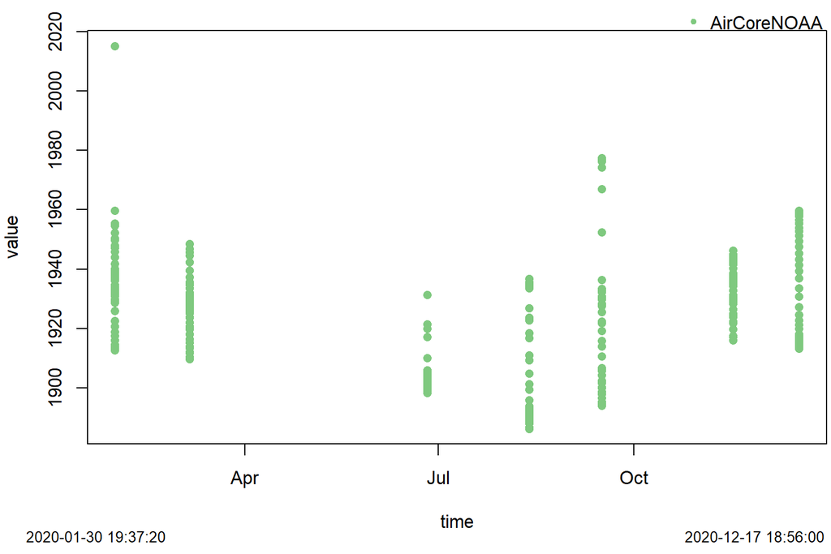

```r
obs_plot(df3, time = "timeUTC", yfactor = 1e9)
```

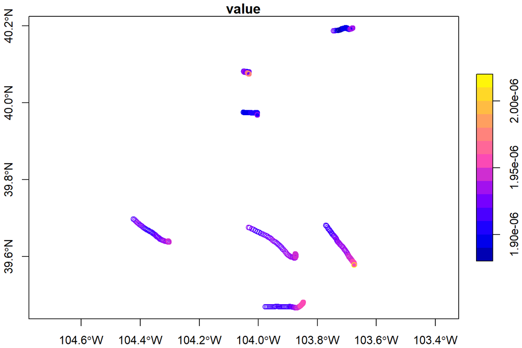

[output not shown]

```r
library(sf)
x <- st_as_sf(df3, coords = c("longitude", "latitude"), crs = 4326)
plot(x["value"], axes = T, reset = F)
maps::map(add = T)
```

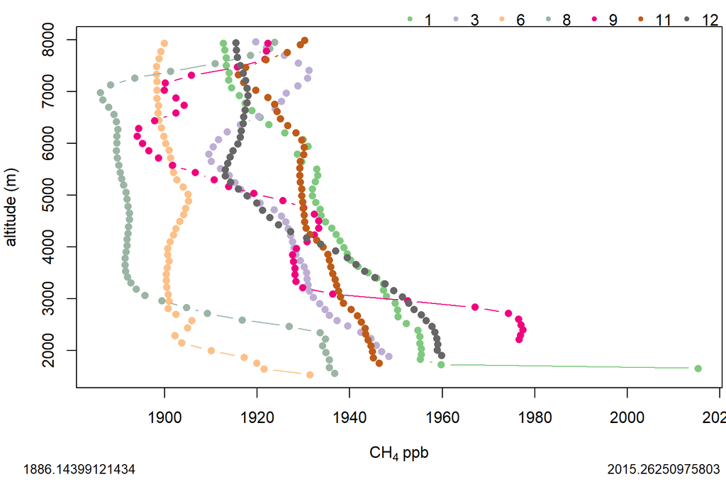

```r
x <- df3
x$ch4 <- x$value*1e+9
obs_plot(x,
         time = "ch4",
         y = "altitude_final",
         colu = "month", n = c(1L, 3L, 6L, 8L, 9L, 11L, 12L),
         type = "b",
         xlab = expression(CH[4]~ppb),
         ylab = "altitude (m)")
```